# 06_ALT_status_tel_ins

Andrea Polazzi

2026-03-18

# Setup

```r
library(readxl)
source('../scripts/clean_columns.R')
data <- read_xlsx('../data/raw/PCAWG_variables_PCA_woK.xlsx')
clean_data <- clean_pcawg_data(data)
model_data_reduced <- clean_data[complete.cases(clean_data), -c(1,2,5)]  # we remove also telomere_insertion_rate
summary(model_data_reduced)
```

```
##     alt_status     tf_rate         telomere_content_log2   TERT_FPKM
##  ALT-low :768   Min.   : 0.00000   Min.   :-2.29092      Min.   : 0.00000
##  ALT-high: 49   1st Qu.: 0.00000   1st Qu.:-0.95324      1st Qu.: 0.02014
##                 Median : 0.03147   Median :-0.55712      Median : 0.10907
##                 Mean   : 0.12777   Mean   :-0.44621      Mean   : 0.91717
##                 3rd Qu.: 0.07243   3rd Qu.:-0.08914      3rd Qu.: 0.39077
##                 Max.   :19.73776   Max.   : 3.84469      Max.   :53.76790
##  ATAGGG_singleton_dist CTAGGG_singleton_dist GTAGGG_singleton_dist
##  Min.   :-3.82135      Min.   :-3.0401       Min.   :-2.43840
##  1st Qu.:-0.56491      1st Qu.:-0.2686       1st Qu.:-0.32314
##  Median : 0.02487      Median : 0.1495       Median : 0.03610
##  Mean   : 0.01321      Mean   : 0.1797       Mean   : 0.03857
##  3rd Qu.: 0.59111      3rd Qu.: 0.6213       3rd Qu.: 0.33915
##  Max.   : 4.47470      Max.   : 2.8541       Max.   : 2.74981
##  TAAGGG_singleton_dist TCAGGG_singleton_dist TGAGGG_singleton_dist
##  Min.   :-3.13241      Min.   :-2.8553       Min.   :-5.27154
##  1st Qu.:-0.53764      1st Qu.:-0.4778       1st Qu.:-0.35882
##  Median : 0.10627      Median : 0.1182       Median : 0.07551
##  Mean   : 0.07596      Mean   : 0.1982       Mean   : 0.10597
##  3rd Qu.: 0.69820      3rd Qu.: 0.7847       3rd Qu.: 0.46824
##  Max.   : 3.81679      Max.   : 7.5686       Max.   : 6.67267
##  TTCGGG_singleton_dist TTGGGG_singleton_dist TTTGGG_singleton_dist
##  Min.   :-3.23509      Min.   :-3.02421      Min.   :-3.80780
##  1st Qu.:-0.48603      1st Qu.:-0.36756      1st Qu.:-0.40600
##  Median : 0.09028      Median :-0.01286      Median : 0.02340
##  Mean   : 0.15567      Mean   : 0.02180      Mean   : 0.00976
##  3rd Qu.: 0.66142      3rd Qu.: 0.44543      3rd Qu.: 0.48155
##  Max.   : 8.73932      Max.   : 3.19366      Max.   : 2.25362
```

# PCA without tel. insertion

```r
X <- scale(model_data_reduced[, -1])
pca <- prcomp(X, center = TRUE, scale. = TRUE)
summary(pca)
```

```
## Importance of components:
##                           PC1    PC2    PC3     PC4     PC5     PC6     PC7
## Standard deviation     1.6826 1.2127 1.1311 0.97563 0.93360 0.92652 0.88095
## Proportion of Variance 0.2359 0.1226 0.1066 0.07932 0.07263 0.07154 0.06467
## Cumulative Proportion  0.2359 0.3585 0.4651 0.54442 0.61706 0.68859 0.75327
##                            PC8     PC9    PC10   PC11    PC12
## Standard deviation     0.84985 0.80408 0.75989 0.7324 0.69147
## Proportion of Variance 0.06019 0.05388 0.04812 0.0447 0.03984
## Cumulative Proportion  0.81345 0.86733 0.91545 0.9602 1.00000
```

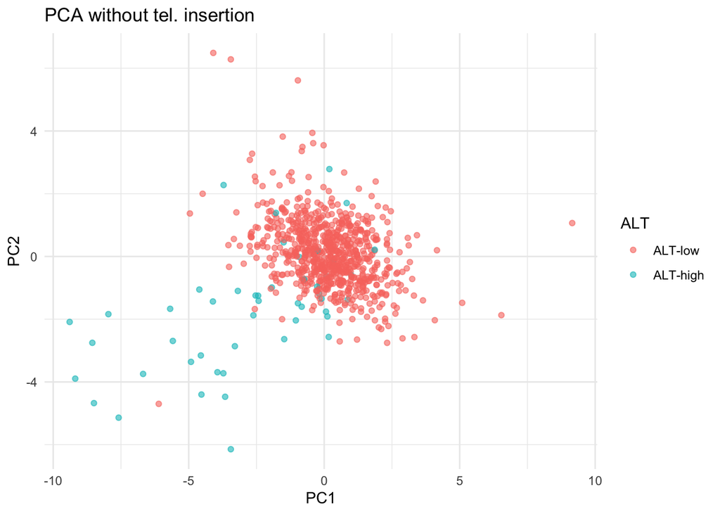

```r
library(ggplot2)
pca_df <- data.frame(
  PC1 = pca$x[,1],
  PC2 = pca$x[,2],
  ALT = model_data_reduced$alt_status
)

ggplot(pca_df, aes(PC1, PC2, color = ALT)) +
  geom_point(alpha = 0.6) +
  theme_minimal() +
  labs(
    title = "PCA without tel. insertion",
    x = "PC1",
    y = "PC2"
  )
```

```r
pca$rotation
```

```
##                               PC1         PC2         PC3         PC4
## tf_rate               -0.18050723 -0.20152254 -0.34965740  0.04083258
## telomere_content_log2 -0.16446516  0.12579057 -0.63331402 -0.02575951
## TERT_FPKM             -0.04877422  0.37827525 -0.46774374 -0.42911277
## ATAGGG_singleton_dist -0.26771644  0.26615485  0.21965844 -0.12417006
## CTAGGG_singleton_dist -0.35153816  0.27620615  0.17604496 -0.12435877
## GTAGGG_singleton_dist -0.26607391 -0.20334789  0.31923118 -0.52795376
## TAAGGG_singleton_dist -0.26925286  0.21744619  0.08304670  0.59558843
## TCAGGG_singleton_dist -0.40381719  0.19592739 -0.07035140  0.01324369
## TGAGGG_singleton_dist -0.37682215 -0.29400343 -0.04665201  0.12908199
## TTCGGG_singleton_dist -0.40194012 -0.31254985  0.05368680 -0.21406581
## TTGGGG_singleton_dist -0.36363650 -0.01097755 -0.02076198  0.29126865
## TTTGGG_singleton_dist  0.02439689  0.58487461  0.24368592 -0.04108734
##                               PC5         PC6         PC7           PC8
## tf_rate                0.76232865  0.44081891  0.02130376  0.0007368119
## telomere_content_log2 -0.24670007  0.01984608 -0.36919280  0.2319823537
## TERT_FPKM              0.05144033 -0.37888917  0.08242106 -0.2457510350
## ATAGGG_singleton_dist -0.20181079  0.52300025 -0.54698919  0.0154026646
## CTAGGG_singleton_dist -0.13217780  0.19443836  0.50107108  0.0239375899
## GTAGGG_singleton_dist  0.21340277 -0.30696533 -0.31739355  0.1182304829
## TAAGGG_singleton_dist  0.16991013 -0.41673509 -0.23662375  0.2392432404
## TCAGGG_singleton_dist -0.09896165  0.12172879  0.36135192  0.3220034232
## TGAGGG_singleton_dist -0.03713631 -0.21712904  0.10842944  0.2074016943
## TTCGGG_singleton_dist -0.01595986 -0.10546377  0.02668138 -0.1268542381
## TTGGGG_singleton_dist -0.08298267 -0.01682599 -0.07407145 -0.8056606871
## TTTGGG_singleton_dist  0.45213481 -0.09553946 -0.03033320 -0.0433732660
##                               PC9         PC10         PC11        PC12
## tf_rate                0.11515742  0.099970365  0.059514051  0.01266161
## telomere_content_log2 -0.48585252  0.068818271  0.217574978 -0.12600129
## TERT_FPKM              0.48041000 -0.041303212 -0.067227774  0.03460802
## ATAGGG_singleton_dist  0.37968625 -0.180309462 -0.056734752 -0.01543420
## CTAGGG_singleton_dist  0.02055565  0.317585784  0.538683794 -0.23513437
## GTAGGG_singleton_dist -0.15769640  0.280531221  0.152980350  0.35462109
## TAAGGG_singleton_dist  0.26320969  0.331947421 -0.044802176 -0.14613809
## TCAGGG_singleton_dist -0.15249823  0.006837006 -0.561662856  0.44246930
## TGAGGG_singleton_dist  0.16610056 -0.692701557  0.359892268  0.11173479
## TTCGGG_singleton_dist -0.09823704 -0.046422075 -0.423129463 -0.68776813
## TTGGGG_singleton_dist -0.20336871  0.032680587  0.041944954  0.27649287
## TTTGGG_singleton_dist -0.42344562 -0.422137070  0.002195329 -0.14963203
```

# Biplot

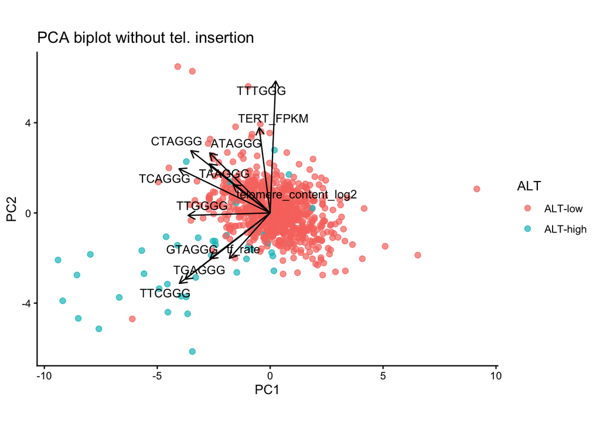

```r
# sample coordinates
scores <- data.frame(
  PC1 = pca$x[,1],
  PC2 = pca$x[,2],
  ALT = model_data_reduced$alt_status
)

# motif vectors
loadings <- data.frame(
  PC1 = pca$rotation[,1],
  PC2 = pca$rotation[,2],
  comp_names = c(rownames(pca$rotation)[1:3], sapply(strsplit(rownames(pca$rotation)[4:12], split = '_', fixed = TRUE), `[`, 1))
)

# scale the loadings (smaller than sample coordinates) to make arrows more visible
loadings$PC1 <- loadings$PC1 * 10
loadings$PC2 <- loadings$PC2 * 10

library(ggplot2)
library(ggrepel)
p <- ggplot(scores, aes(PC1, PC2, color = ALT)) +
  geom_point(alpha = 0.7, size = 2) +

  geom_segment(data = loadings,
               aes(x = 0, y = 0, xend = PC1, yend = PC2),
               arrow = arrow(length = unit(0.25,"cm")),
               inherit.aes = FALSE,
               color = "black") +

  geom_text_repel(data = loadings,
                  aes(PC1, PC2, label = comp_names),
                  inherit.aes = FALSE,
                  size = 3.5) +

  theme_classic() +
  coord_equal() +
  labs(
    title = "PCA biplot without tel. insertion",
    x = "PC1",
    y = "PC2"
  )

plot(p)
```

```r
ggsave("../outputs/PCA_biplot_red_telins.pdf", plot = p, width = 7, height = 6)
```

Comparing the two PCA biplots, the most evident change **after removing telomere insertion rate** is the **reduction of the strong directional signal toward the lower-left quadrant**. In the full-feature PCA, the telomere insertion rate vector is long and points strongly in that direction, and many ALT-high tumors lie along this axis, indicating that this variable contributes substantially to the separation between ALT-high and ALT-low samples. Once this feature is removed, the PCA structure becomes more centered and the remaining variables distribute more evenly around the origin. The ALT-high samples still tend to occupy the lower-left region of the plot, but **the separation from ALT-low tumors becomes less pronounced**. The remaining vectors, particularly **TGAGGG, TTCGGG, GTAGGG, and TF rate—continue to point toward this region**, suggesting that **these variables now capture part of the variance previously dominated by telomere insertion rate**.

# Split the dataset

```r
set.seed(21)

train_index <- sample(1:nrow(model_data_reduced), size=0.7*nrow(model_data_reduced))
train_red <- model_data_reduced[train_index,]
test_red <- model_data_reduced[-train_index,]

# Check distribution
table(train_red$alt_status, dnn = 'train')
```

```
## train
##  ALT-low ALT-high
##      537       34
```

```r
table(test_red$alt_status, dnn = 'test')
```

```
## test
##  ALT-low ALT-high
##      231       15
```

# First classifier: Logistic Regression

```r
logreg_model_reduced <- glm(
  alt_status ~ .,
  data = train_red,
  family = "binomial"
)

prob_red <- predict(
  logreg_model_reduced,
  test_red,
  type = "response"
)
```

## Evaluate performance

```r
library(pROC, quietly = T)
roc_red <- roc(
  test_red$alt_status,
  prob_red,
  levels = c("ALT-low","ALT-high")
)
```

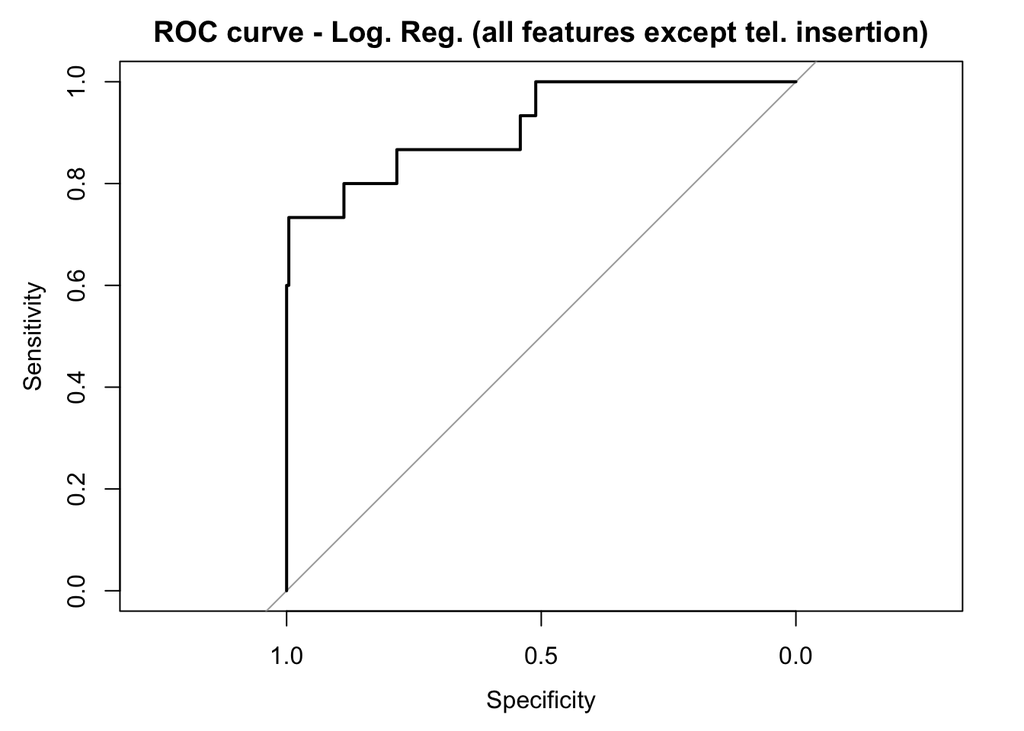

```r
plot(roc_red, main = 'ROC curve - Log. Reg. (all features except tel. insertion)')
```

```r
auc(roc_red)
```

```
## Area under the curve: 0.9143
```

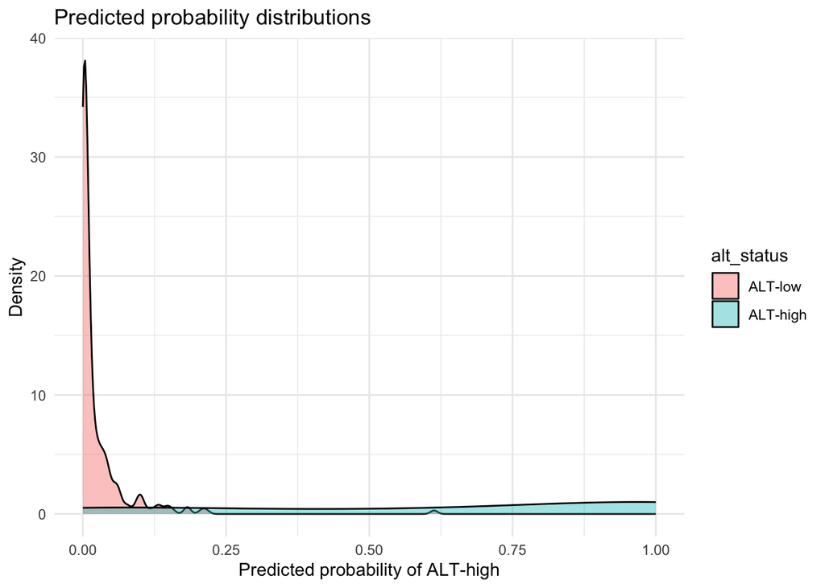

```r
prob_df <- data.frame(
  prob = prob_red,
  alt_status = test_red$alt_status
)

library(ggplot2)

ggplot(prob_df, aes(x = prob, fill = alt_status)) +
  geom_density(alpha = 0.4) +
  theme_minimal() +
  labs(
    title = "Predicted probability distributions",
    x = "Predicted probability of ALT-high",
    y = "Density"
  )
```

### Other metrics

```r
pred_class <- ifelse(prob_red >= 0.5, "ALT-high", "ALT-low")
pred_class <- factor(pred_class, levels = c("ALT-low", "ALT-high"))

library(caret, quietly = TRUE)
confusionMatrix(pred_class, test_red$alt_status, positive = 'ALT-high')
```

```
## Confusion Matrix and Statistics
##
##           Reference
## Prediction ALT-low ALT-high
##   ALT-low      230        5
##   ALT-high       1       10
##
##                Accuracy : 0.9756
##                  95% CI : (0.9477, 0.991)
##     No Information Rate : 0.939
##     P-Value [Acc > NIR] : 0.006358
##
##                   Kappa : 0.7567
##
##  Mcnemar's Test P-Value : 0.220671
##
##             Sensitivity : 0.66667
##             Specificity : 0.99567
##          Pos Pred Value : 0.90909
##          Neg Pred Value : 0.97872
##              Prevalence : 0.06098
##          Detection Rate : 0.04065
##    Detection Prevalence : 0.04472
##       Balanced Accuracy : 0.83117
##
##        'Positive' Class : ALT-high
##
```

When telomere insertion rate is removed, the logistic regression model still achieves strong predictive performance. The model reaches an **AUC of 0.914**, indicating excellent discrimination between ALT-high and ALT-low tumors even without the strongest structural telomere feature. The confusion matrix shows a **high overall accuracy of 97.6%** and a **balanced accuracy of 0.83**, reflecting strong performance despite the class imbalance. The model maintains **very high specificity (0.996)**, meaning that ALT-low tumors are almost never misclassified, while **sensitivity is moderate (0.67)**, indicating that roughly two thirds of ALT-high tumors are correctly detected. The **positive predictive value of 0.91** further indicates that most tumors predicted as ALT-high are true positives.

# Second classifier: Random Forest

```r
library(randomForest, quietly = T)
rf_red <- randomForest(
  alt_status ~ .,
  data = train_red,
  ntree = 500,
  importance = TRUE
)

rf_pred_red <- predict(
  rf_red,
  test_red,
  type = "prob"
)[,"ALT-high"]
```

## Evaluate performance

```r
roc_rf_red <- roc(
  test_red$alt_status,
  rf_pred_red,
  levels = c("ALT-low","ALT-high")
)
```

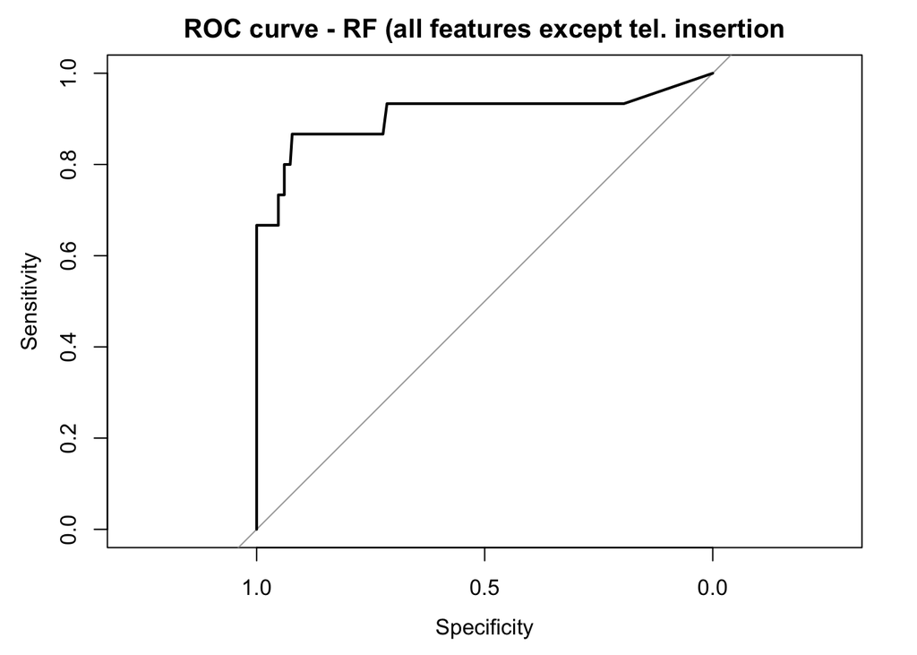

```r
plot(roc_rf_red, main = 'ROC curve - RF (all features except tel. insertion')
```

```r
auc(roc_rf_red)
```

```
## Area under the curve: 0.9088
```

### Other metrics

```r
rf_pred_red <- ifelse(rf_pred_red >= 0.5, "ALT-high", "ALT-low")
rf_pred_red <- factor(rf_pred_red, levels = c("ALT-low", "ALT-high"))

library(caret)

confusionMatrix(
  rf_pred_red,
  test_red$alt_status,
  positive = "ALT-high"
)
```

```
## Confusion Matrix and Statistics
##
##           Reference
## Prediction ALT-low ALT-high
##   ALT-low      231        6
##   ALT-high       0        9
##
##                Accuracy : 0.9756
##                  95% CI : (0.9477, 0.991)
##     No Information Rate : 0.939
##     P-Value [Acc > NIR] : 0.006358
##
##                   Kappa : 0.738
##
##  Mcnemar's Test P-Value : 0.041227
##
##             Sensitivity : 0.60000
##             Specificity : 1.00000
##          Pos Pred Value : 1.00000
##          Neg Pred Value : 0.97468
##              Prevalence : 0.06098
##          Detection Rate : 0.03659
##    Detection Prevalence : 0.03659
##       Balanced Accuracy : 0.80000
##
##        'Positive' Class : ALT-high
##
```

When telomere insertion rate is removed, the Random Forest classifier still achieves strong discriminatory performance, with an **AUC of approximately 0.91**. This is very similar to the logistic regression reduced model and indicates that the remaining predictors—TF rate, telomere content, TERT expression, and TVR motifs—retain substantial information about ALT status. The confusion matrix shows a **high overall accuracy (97.6%)** and a **balanced accuracy of 0.80**, confirming that the model remains highly effective despite the removal of the strongest structural telomere feature.

The model exhibits **perfect specificity (1.00)**, meaning that ALT-low tumors are never misclassified as ALT-high in this split. However, **sensitivity is moderate (0.60)**, indicating that some ALT-high tumors remain difficult to detect when telomere insertion rate is excluded. The **positive predictive value of 1.00** shows that when the model predicts ALT-high, the prediction is always correct in this dataset. Overall, the model remains highly reliable but detects slightly fewer ALT-high cases compared with the full model.

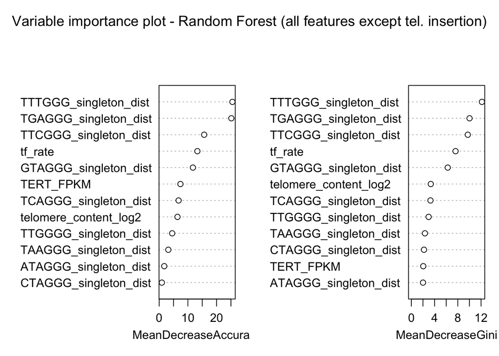

```r
varImpPlot(rf_red, main = 'Variable importance plot - Random Forest (all features except tel. insertion)' )
```

Together, the PCA and the classifier results therefore suggest that while telomere insertion rate is a dominant driver of discrimination, a combination of **TVR motifs and other telomere-related features still provides substantial predictive information** about the ALT status.

# Cross Validation of the performances

To assess the robustness of these two predictive models, we conducted **repeated stratified cross-validation**.

## Logistic Regression - CV

```r
library(pROC)

set.seed(21)

cv_data <- model_data_reduced
k <- 5
n_repeats <- 5

auc_results <- c()

for (r in 1:n_repeats) {
  # stratified fold assignment
  fold_id <- integer(nrow(cv_data))

  idx_low  <- which(cv_data$alt_status == "ALT-low")
  idx_high <- which(cv_data$alt_status == "ALT-high")

  fold_id[idx_low]  <- sample(rep(1:k, length.out = length(idx_low)))
  fold_id[idx_high] <- sample(rep(1:k, length.out = length(idx_high)))

  for (fold in 1:k) {
    train_cv <- cv_data[fold_id != fold, ]
    test_cv  <- cv_data[fold_id == fold, ]

    logreg_cv_model <- glm(alt_status~., data = train_cv, family = 'binomial')

    logreg_cv_prob <- predict(logreg_cv_model, test_cv, type = 'response')

    roc_obj <- roc(
      response = test_cv$alt_status,
      predictor = logreg_cv_prob,
      levels = c("ALT-low", "ALT-high")
    )

    auc_results <- c(auc_results, as.numeric(auc(roc_obj)))
  }
}

mean(auc_results)
```

```
## [1] 0.8976512
```

```r
# sd(auc_results)
# auc_results
```

## Random Forest - CV

```r
library(randomForest)
library(pROC)

set.seed(21)

cv_data <- model_data_reduced
k <- 5
n_repeats <- 5

auc_results <- c()

for (r in 1:n_repeats) {
  # stratified fold assignment
  fold_id <- integer(nrow(cv_data))

  idx_low  <- which(cv_data$alt_status == "ALT-low")
  idx_high <- which(cv_data$alt_status == "ALT-high")

  fold_id[idx_low]  <- sample(rep(1:k, length.out = length(idx_low)))
  fold_id[idx_high] <- sample(rep(1:k, length.out = length(idx_high)))

  for (fold in 1:k) {
    train_cv <- cv_data[fold_id != fold, ]
    test_cv  <- cv_data[fold_id == fold, ]

    rf_cv_model <- randomForest(
      alt_status ~ .,
      data = train_cv,
      ntree = 500,
      mtry = 2
    )

    rf_cv_prob <- predict(rf_cv_model, test_cv, type = "prob")[, "ALT-high"]

    roc_obj <- roc(
      response = test_cv$alt_status,
      predictor = rf_cv_prob,
      levels = c("ALT-low", "ALT-high")
    )

    auc_results <- c(auc_results, as.numeric(auc(roc_obj)))
  }
}

mean(auc_results)
```

```
## [1] 0.9192728
```

```r
# sd(auc_results)
# auc_results
```

These results confirm the **robustness of the AUC values previously recorded** for the two models, and agree with the fact that allowing non-linear relationships among features (i.e. using Random Forest) provide a better classification power.